# DATA 605: Computational Mathematics Homework 3

Gabriel Campos

Last edited November 27, 2024

## Library

```r
# Data load
data(cars)
# libraries
library(dplyr)
library(ggplot2)
library(ggthemes)
library(lmtest)
```

# Problem 1

**Transportation Safety**

**Task**

Using the cars dataset in R, perform the following steps:

## 1

**Data Visualization**

### i

Create a scatter plot of stopping distance (dist) as a function of speed (speed).

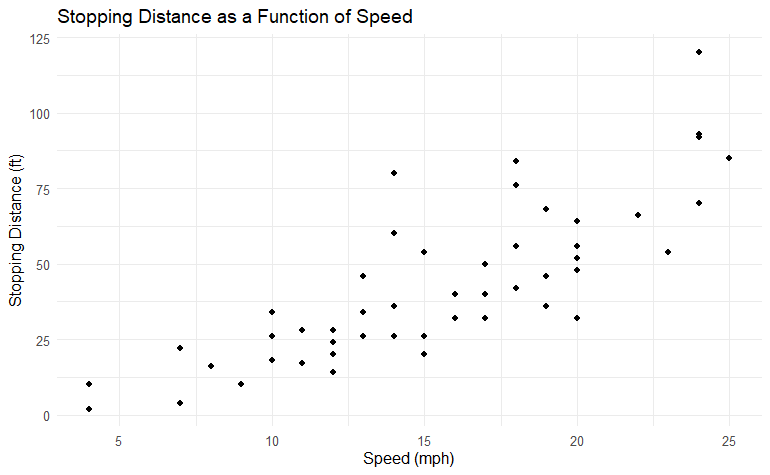

```r
ggplot(cars, aes(x = speed, y = dist)) +
  geom_point() +
  labs(
    title = "Stopping Distance as a Function of Speed",
    x = "Speed (mph)",
    y = "Stopping Distance (ft)"
  ) +
  theme_minimal()
```

### ii

Add a regression line to the plot to visually assess the relationship.

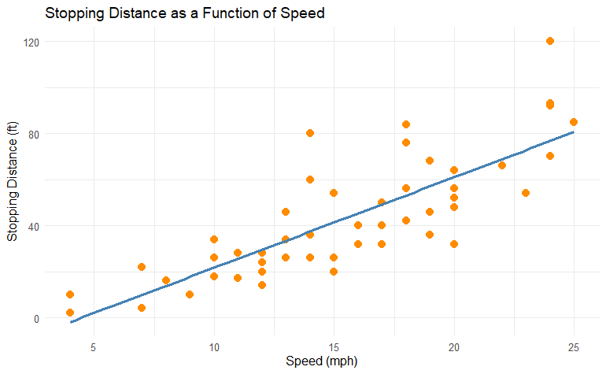

```r
ggplot(cars, aes(x = speed, y = dist)) +
  geom_point(color = "darkorange", size = 3) +
  geom_smooth(method = "lm", color = "steelblue", se = FALSE) +
  labs(
    title = "Stopping Distance as a Function of Speed",
    x = "Speed (mph)",
    y = "Stopping Distance (ft)"
  ) +
  theme_minimal()
```

## 2

**Build a Linear Model**

### i

Construct a simple linear regression model where stopping distance (dist) is the dependent variable and speed (speed) is the independent variable.

```r
cars_model <- lm(dist~speed, data = cars)
```

### ii

Summarize the model to evaluate its coefficients, R-squared value, and p-value.

```r
summary(cars_model)
```

```
Call:
lm(formula = dist ~ speed, data = cars)

Residuals:
    Min      1Q  Median      3Q     Max
-29.069  -9.525  -2.272   9.215  43.201

Coefficients:
            Estimate Std. Error t value Pr(>|t|)
(Intercept) -17.5791     6.7584  -2.601   0.0123 *
speed         3.9324     0.4155   9.464 1.49e-12 ***
---
Signif. codes:  0 ‘***’ 0.001 ‘**’ 0.01 ‘*’ 0.05 ‘.’ 0.1 ‘ ’ 1

Residual standard error: 15.38 on 48 degrees of freedom
Multiple R-squared:  0.6511,    Adjusted R-squared:  0.6438
F-statistic: 89.57 on 1 and 48 DF,  p-value: 1.49e-12
```

- **Intercept & Speed** of -17.5791 just indicates the stopping distance at 0 mph. The value is not important only because logically a vehicle not in motion (0mph) does not require stopping distance. The value of $3.9324$ indicates for every 1 mph $3.9324 \ ft$ is needed to stop. Therefore a minimum speed of $\approx 4.48 \ mph$ is needed before any distance is actually needed to stop.
- **R-Squared** value of $0.6511$ indicates $\approx 65\%$ of variance is captured by this relationship, so its a moderate indicator, and there may be several more and potentially stronger factor that can be used to predict the distance needed to stop.
- **P-Value** of $1.49e^{12}$ indicates that the relationship is statistically significant.

### 3

**Model Quality Evaluation**

### i

Calculate and interpret the R-squared value to assess the proportion of variance in stopping distance explained by speed.

- **R-Squared** as indicated above this means $\approx 65\%$ of the variance is captured, making this a moderate factor to stopping distance.
- **R-Squared Adjusted** Frankly, there is only 2 attributes to this table, so adjusting according to the number of predictors of the model makes little difference, therefore the variance of $0.6438$ or $\approx 64\%$ is relatively the same to the original, and the remaining factors would include attributes not collected in our dataset.

### ii

Perform a residual analysis to check the assumptions of the linear regression model, including linearity, homoscedasticity, independence, and normality of residuals.

**In order to do this without repeating the steps for Section 4 we leverage the various functions in R through the package [lmtest](https://cran.r-project.org/web/packages/lmtest/index.html)**

```r
cars_resid_values <- resid(cars_model)
cars_fitted_values <- fitted(cars_model)
```

```r
summary(cars_resid_values)
```

```
   Min. 1st Qu.  Median    Mean 3rd Qu.    Max.
-29.069  -9.525  -2.272   0.000   9.215  43.201
```

```r
lmtest::bptest(cars_model)
```

```
    studentized Breusch-Pagan test

data:  cars_model
BP = 3.2149, df = 1, p-value = 0.07297
```

```r
cor(cars_fitted_values, cars$dist)
```

```
[1] 0.8068949
```

```r
dwtest(cars_model)
```

```
    Durbin-Watson test

data:  cars_model
DW = 1.6762, p-value = 0.09522
alternative hypothesis: true autocorrelation is greater than 0
```

```r
ks.test(cars_resid_values, "pnorm", mean=mean(cars_resid_values, sd = sd(cars_resid_values)))
```

```
    Asymptotic one-sample Kolmogorov-Smirnov test

data:  cars_resid_values
D = 0.49833, p-value = 3.283e-11
alternative hypothesis: two-sided
```

## 4

**Residual Analysis**

### i

Plot the residuals versus fitted values to check for any patterns.

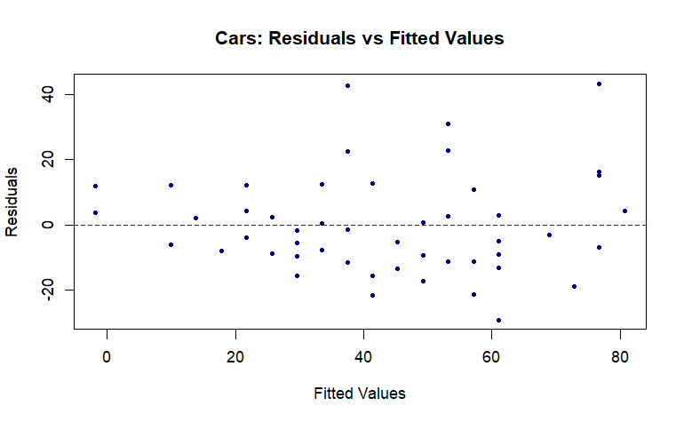

```r
plot(cars_fitted_values, cars_resid_values,
     xlab = "Fitted Values",
     ylab = "Residuals",
     main = "Cars: Residuals vs Fitted Values",
     pch = 20,
     col = "navyblue")
abline(h = 0, col = "darkred", lty = 2)
```

### ii

Create a Q-Q plot of the residuals to assess normality.

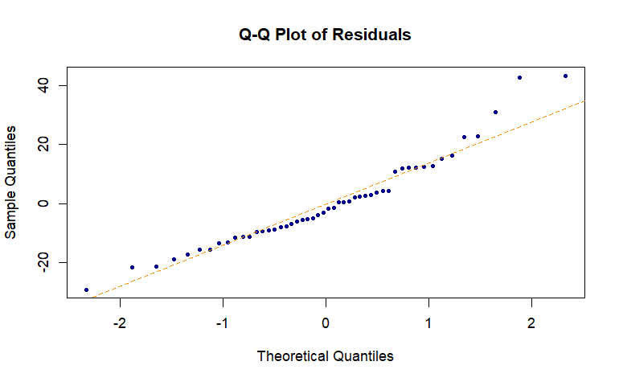

```r
qqnorm(cars_resid_values,
       main = "Q-Q Plot of Residuals",
       pch = 20,
       col = "darkblue")
qqline(cars_resid_values, col = "darkorange", lty = 2)
```

### iii

Perform a Shapiro-Wilk test for normality of residuals.

```r
cars_shapiro_test <- shapiro.test(cars_resid_values)
cars_shapiro_test
```

```
    Shapiro-Wilk normality test

data:  cars_resid_values
W = 0.94509, p-value = 0.02152
```

### iv

Plot a histogram of residuals to further check for normality.

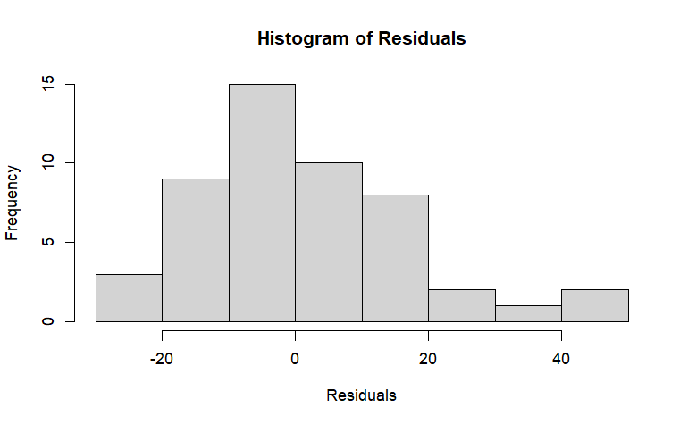

```r
hist(cars_resid_values,
     breaks = 10, # Adjust the number of bins as needed
     col = "lightgrey",
     main = "Histogram of Residuals",
     xlab = "Residuals",
     ylab = "Frequency",
     border = "black")
```

### Conclusion

Based on the model summary and residual analysis, determine whether the linear model is appropriate for this data. Discuss any potential violations of model assumptions and suggest improvements if necessary.

The model for this data set is reasonably appropriate, as it demonstrates moderate explanatory power $(R^2 \approx 0.65)$. While the Q-Q plot and histogram suggest residuals indicate near-normal residuals, the Shapiro-Wilk test $(p=0.02152)$ suggests mild non-normality. Additionally, the residuals vs fitted plot reveals 3 outliers that may impact the models validity. To improve the model, we can consider removing or adjusting for these outliers or testing a non-linear regression model to capture potential curvature in the data.

# Problem 2

**Health Policy Analyst**

As a health policy analyst for an international organization, you are tasked with analyzing data from the World Health Organization (WHO) to inform global health policies. The dataset provided (who.csv) contains crucial health indicators for various countries from the year 2008. The variables include:

- Country: Name of the country
- LifeExp: Average life expectancy for the country in years
- InfantSurvival: Proportion of those surviving to one year or more
- Under5Survival: Proportion of those surviving to five years or more
- TBFree: Proportion of the population without TB
- PropMD: Proportion of the population who are MDs
- PropRN: Proportion of the population who are RNs
- PersExp: Mean personal expenditures on healthcare in US dollars at average exchange rate
- GovtExp: Mean government expenditures per capita on healthcare, US dollars at average exchange rate
- TotExp: Sum of personal and government expenditures

Your analysis will directly influence recommendations for improving global life expectancy and the allocation of healthcare resources.

```r
who_df <- read.csv("who.csv", fileEncoding = "UTF-8")%>%
              select(-LifeExp.1,-X)
```

## Question 1

**Initial Assessment of Healthcare Expenditures and Life Expectancy**

**Task**

Create a scatterplot of LifeExp vs. TotExp to visualize the relationship between healthcare expenditures and life expectancy across countries. Then, run a simple linear regression with LifeExp as the dependent variable and TotExp as the independent variable (without transforming the variables).

- Provide and interpret the F-statistic, R-squared value, standard error, and p-values.
- Discuss whether the assumptions of simple linear regression (linearity, independence, homoscedasticity, and normality of residuals) are met in this analysis.

```r
str(who_df)
```

```
'data.frame':   42 obs. of  10 variables:
 $ Country       : chr  "Afghanistan" "Albania" "Algeria" "Andorra" ...
 $ LifeExp       : int  42 71 71 82 41 73 75 69 82 80 ...
 $ InfantSurvival: num  0.835 0.985 0.967 0.997 0.846 0.99 0.986 0.979 0.995 0.996 ...
 $ Under5Survival: num  0.743 0.983 0.962 0.996 0.74 0.989 0.983 0.976 0.994 0.996 ...
 $ TBFree        : num  0.998 1 0.999 1 0.997 ...
 $ PropMD        : num  2.29e-04 1.14e-03 1.06e-03 3.30e-03 7.04e-05 ...
 $ PropRN        : num  0.000572 0.004614 0.002091 0.0035 0.001146 ...
 $ PersExp       : int  20 169 108 2589 36 503 484 88 3181 3788 ...
 $ GovtExp       : int  92 3128 5184 169725 1620 12543 19170 1856 187616 189354 ...
 $ TotExp        : int  112 3297 5292 172314 1656 13046 19654 1944 190797 193142 ...
```

```r
summary(who_df)
```

```
   Country             LifeExp      InfantSurvival   Under5Survival
 Length:42          Min.   :41.00   Min.   :0.8350   Min.   :0.7400
 Class :character   1st Qu.:62.00   1st Qu.:0.9270   1st Qu.:0.9110
 Mode  :character   Median :71.00   Median :0.9810   Median :0.9790
                    Mean   :66.76   Mean   :0.9561   Mean   :0.9357
                    3rd Qu.:75.00   3rd Qu.:0.9900   3rd Qu.:0.9880
                    Max.   :82.00   Max.   :0.9970   Max.   :0.9960
                    NA's   :1       NA's   :1        NA's   :1
     TBFree           PropMD              PropRN
 Min.   :0.9929   Min.   :0.0000245   Min.   :0.0001649
 1st Qu.:0.9973   1st Qu.:0.0001719   1st Qu.:0.0007410
 Median :0.9993   Median :0.0010471   Median :0.0019340
 Mean   :0.9982   Mean   :0.0012641   Mean   :0.0032899
 3rd Qu.:0.9997   3rd Qu.:0.0014286   3rd Qu.:0.0046694
 Max.   :1.0000   Max.   :0.0047587   Max.   :0.0140792
 NA's   :1        NA's   :1           NA's   :1
    PersExp          GovtExp           TotExp
 Min.   :   3.0   Min.   :    10   Min.   :    13
 1st Qu.:  36.0   1st Qu.:   780   1st Qu.:   833
 Median : 198.0   Median :  5394   Median :  5574
 Mean   : 603.5   Mean   : 32547   Mean   : 33150
 3rd Qu.: 484.0   3rd Qu.: 19604   3rd Qu.: 20035
 Max.   :3788.0   Max.   :239105   Max.   :242556
 NA's   :1        NA's   :1        NA's   :1
```

**Create a scatterplot of LifeExp vs. TotExp**

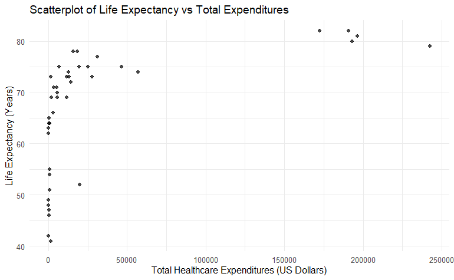

```r
ggplot(who_df, aes(x = TotExp, y = LifeExp)) +
  geom_point(alpha = 0.7) +
  labs(
    title = "Scatterplot of Life Expectancy vs Total Expenditures",
    x = "Total Healthcare Expenditures (US Dollars)",
    y = "Life Expectancy (Years)"
  ) +
  theme_minimal()
```

```r
who_model <- lm(LifeExp ~ TotExp, data = who_df)
```

```r
summary(who_model)
```

```
Call:
lm(formula = LifeExp ~ TotExp, data = who_df)

Residuals:
    Min      1Q  Median      3Q     Max
-22.720  -7.944   2.157   7.122  12.926

Coefficients:
             Estimate Std. Error t value Pr(>|t|)
(Intercept) 6.356e+01  1.788e+00  35.553  < 2e-16 ***
TotExp      9.641e-05  2.493e-05   3.867 0.000406 ***
---
Signif. codes:  0 ‘***’ 0.001 ‘**’ 0.01 ‘*’ 0.05 ‘.’ 0.1 ‘ ’ 1

Residual standard error: 10.15 on 39 degrees of freedom
  (1 observation deleted due to missingness)
Multiple R-squared:  0.2772,    Adjusted R-squared:  0.2587
F-statistic: 14.96 on 1 and 39 DF,  p-value: 0.0004064
```

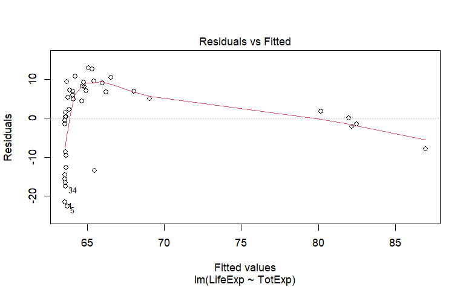

```r
#Residuals vs Fitted
plot(who_model, which = 1)
```

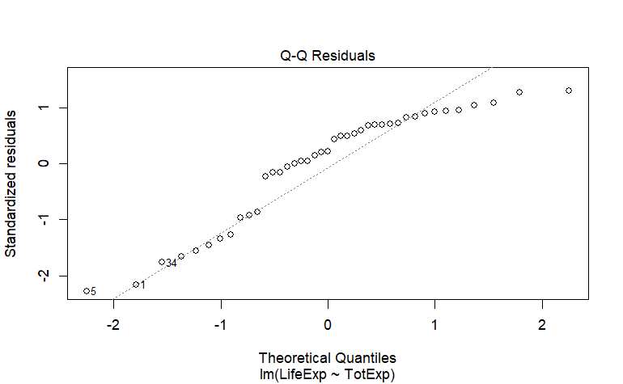

```r
# Q-Q plot
plot(who_model, which = 2)
```

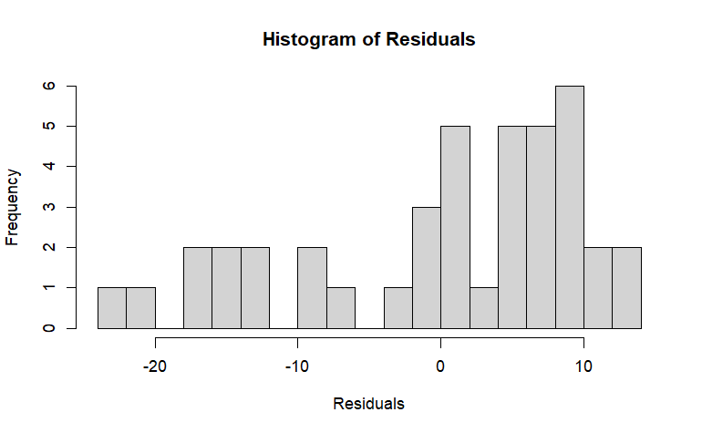

```r
# Histogram of residuals
hist(residuals(who_model), breaks = 20, main = "Histogram of Residuals", xlab = "Residuals")
```

**Discussion**

### i.

Consider the implications of your findings for health policy. Are higher healthcare expenditures generally associated with longer life expectancy?

The data shows a moderate positive relationship between healthcare expenditures and life expectancy.

- $F-statistic$ of $14.96$ and $p-value \approx 0.0004$ indicates statistical significance, suggesting the variables have a meaningful relationship with life expectancy. However, the models explains limited variability in life expectancy.
- Standard Error $(SE)$ of $10.15$ suggests a relatively good fit,providing reasonable precision of the estimating regression coefficient such as slope or intercept.
- A positive coefficient $9.641 \times 10^{-5}$ implies as healthcare expenditure increases, life expectancy improves. However, the magnitude suggests a small incremental effect.
- The residuals deviates significantly from normality, as shown by the Q-Q plot and supported by the Histogram of Residuals.
- There are no evident signs of homoscedasticity. The points do not show randomness or form a funnel or fan like shape.
- There is a clear pattern with the residuals, which do not appear random, with a visible curvature. This indicates a non-linear relationship between the variables, and makes it innappropriate to assume independence of residuals.

### ii.

What do the assumptions of the regression model suggest about the reliability of this relationship? $R^2 = 0.2772$ suggests the relationship is no particularly strong, implying that while healthcare expenditures explain some variation in life expectancy, the model does not capture all the influencing factors.

## Question 2

**Transforming Variables for a Better Fit**

**Task**

Recognizing potential non-linear relationships, transform the variables as follows

- Raise life expectancy to the 4.6 power (LifeExp^4.6).
- Raise total expenditures to the 0.06 power (TotExp^0.06), which is nearly a logarithmic transformation.

Create a new scatterplot with the transformed variables and re-run the simple linear regression model.

- Provide and interpret the F-statistic, R-squared value, standard error, and p-values for the transformed model.
- Compare this model to the original model (from Question 1). Which model provides a better fit, and why?

```r
who_df$LifeExp_t <- who_df$LifeExp^4.6
who_df$TotExp_t <- who_df$TotExp^0.6
```

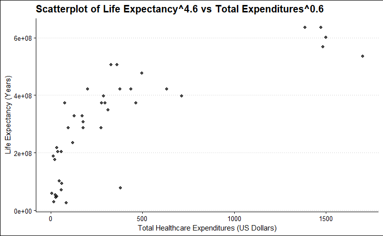

```r
ggplot(who_df, aes(x = TotExp_t, y = LifeExp_t)) +
  geom_point(alpha = 0.7) +
  labs(
    title = "Scatterplot of Life Expectancy^4.6 vs Total Expenditures^0.6",
    x = "Total Healthcare Expenditures (US Dollars)",
    y = "Life Expectancy (Years)"
  ) +
  theme_clean()
```

```r
who_model_t <- lm(LifeExp_t ~ TotExp_t, data = who_df)
summary(who_model_t)
```

```
Call:
lm(formula = LifeExp_t ~ TotExp_t, data = who_df)

Residuals:
       Min         1Q     Median         3Q        Max
-230855907 -109289555   10242350   89067282  211587690

Coefficients:
             Estimate Std. Error t value Pr(>|t|)
(Intercept) 196498750   23177824   8.478 2.21e-10 ***
TotExp_t       295518      39460   7.489 4.61e-09 ***
---
Signif. codes:  0 ‘***’ 0.001 ‘**’ 0.01 ‘*’ 0.05 ‘.’ 0.1 ‘ ’ 1

Residual standard error: 116900000 on 39 degrees of freedom
  (1 observation deleted due to missingness)
Multiple R-squared:  0.5898,    Adjusted R-squared:  0.5793
F-statistic: 56.09 on 1 and 39 DF,  p-value: 4.61e-09
```

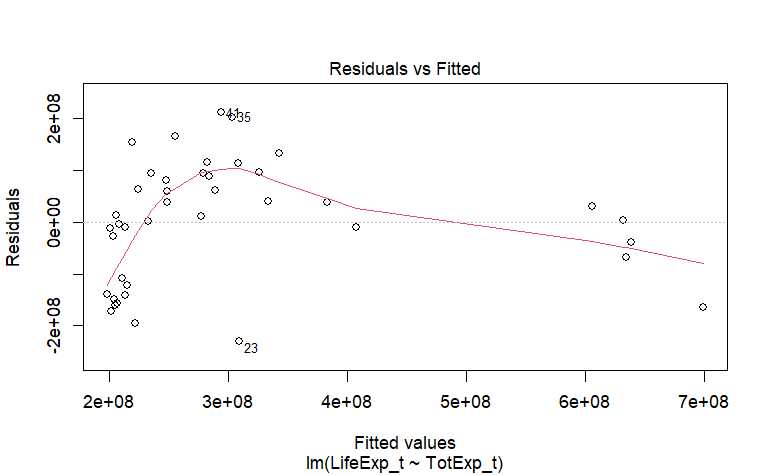

```r
#Residuals vs Fitted
plot(who_model_t, which = 1)
```

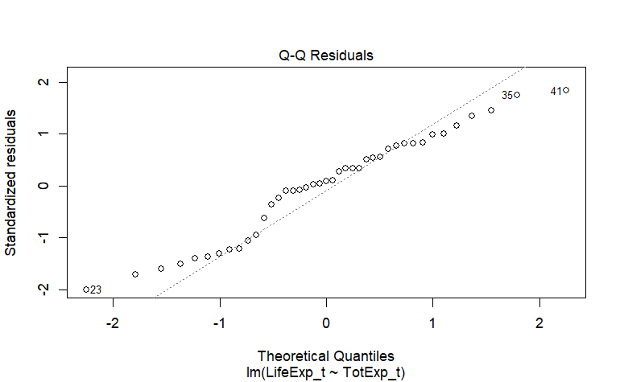

```r
# Q-Q plot
plot(who_model_t, which = 2)
```

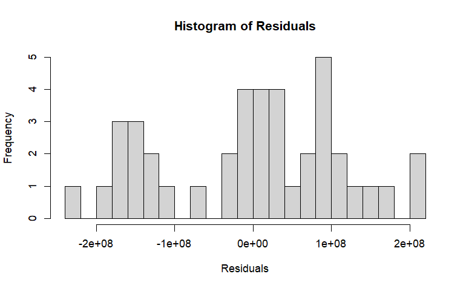

```r
# Histogram of residuals
hist(residuals(who_model_t), breaks = 20, main = "Histogram of Residuals", xlab = "Residuals")
```

- $F-statistic$ of $56.09$ and $p-value = 4.61 \times 10^{9}$ indicates the transformed model is statistical significance and captures greater proportion of variability.
- Standard Error $(SE)$ of $116,900,000$ suggests a worse fit with the precision of the estimated regression coefficient. However, this is more likely a result of the greater magnitude of the transformed variables rather than an actual decline in performance.
- Positive coefficient $295,518$ implies as healthcare expenditure increases so does life expectancy still, reflecting a stronger relationship compared to the original model.
- The residuals appear more normalized, as shown with the Histogram of Residuals and Q-Q plot. Deviations are still present, however they are less severe than the original model.
- No homoscedasticity appears with the transformation.
- Residual patterns still do not support independence between the variables.

**Discussion**

### i

How do the transformations impact the interpretation of the relationship between healthcare spending and life expectancy?

$R^2 = 0.5898$ suggests the relationship is strong, particularly when compare to the predecessor.

### ii

Why might the transformed model be more appropriate for policy recommendations?

The stronger relationship is highlighted after the transformation, which better accounts for the complex, non-linear relationship between healthcare expenditures and life expectancy. This approach reduces risk in model specification and captures the diminishing return on healthcare spending, that has less of an impact after a certain threshold.